# Exploring the BRFSS data

## Setup

### Load packages

```r
library(ggplot2)
library(dplyr)
```

### Load data

Make sure your data and R Markdown files are in the same directory. When loaded your data file will be called `brfss2013`. Delete this note when before you submit your work.

```r
load("brfss2013.RData")
```

## Part 1: Data

- Following the document on the BRFSS website and description, the survey accessed to the respondets with two ways, landline telephone and cellular phone call.
- Home telephone numbers are obtained through random-digit dialing. In terms of sampling, disproportionate strattified random sampling was applied. There are also standard for an eligible adult and if there are right respondents in each household, an adult was randomly selected. When it comes to cellular telephone sampling, the numbers were also randomly generated and randomly selected.
- As we can see, the respondents were randomly selected through many steps so it seems the data collection has generalizability. However, some part of this data was gained from adults who got the cellular phone and they participated(no random sampling). Owning personal celllular phone or landline telephone itself can make the respondents lose randomness. So it is hard to say there is generalizability. In this collection, the answers from randomly selected people were only “observed”. Therefore, it is also hard to say this data has causality as there was no experiments.

## Part 2: Research questions

#### **Research quesion 1: Is there obvious association between age and general health?**

We know our physical ability is not the same as before as time goes by. Is it fair enough to say it is general?

- The variables of interest :
  - ctelenum (Correct telephone number?)
  - _ageg5yr (Reported Age In Five-Year Age Categories Calculated Variable)
  - genhlth (General Health)

#### **Research quesion 2: When subjects are in same generation and have similar drinks consumption, is there any difference between physically active and inactive people in general health?**

As one of the drinkers, I enjoy drinking beer and wine! To enjoy more driking occasions as long as I can, I want to stay healthy. I won’t be able to find causality between them but is there any relationship?

- The variables of interest :
  - _pacat1 (Physical Activity Categories)
  - _ageg5yr (Reported Age In Five-Year Age Categories Calculated Variable)
  - _drnkdy4(Computed Number Of Drinks Of Alcohol Beverages Per Day)

#### **Research quesion 3: Does income level have lingkage with satisfaction of life?**

We want more money and greed has no limits. If you earn more money, would you feel more satisfied with your life? I can’t generalize it as it is limited data but I would like to find out whether there is difference.

- The variables of interest :
  - income2 (Income Level)
  - lsatisfy(Satisfaction With Life)

## Part 3: Exploratory data analysis

NOTE: Insert code chunks as needed by clicking on the “Insert a new code chunk” button (green button with orange arrow) above. Make sure that your code is visible in the project you submit. Delete this note when before you submit your work.

**Research quesion 1: Is there obvious association between age and general health?**

```r
# I need three columns, ctelenum (Correct telephone number?), X_ageg5yr (Reported Age In Five-Year Age Categories Calculated Variable), and genhlth (General Health).

brfss2013 %>% group_by(ctelenum) %>% summarise(count=n())
```

```
## # A tibble: 2 x 2
##   ctelenum  count
##   <fct>     <int>
## 1 Yes      491734
## 2 <NA>         41
```

```r
brfss2013 %>% group_by(X_ageg5yr) %>% summarise(count=n())
```

```
## # A tibble: 14 x 2
##    X_ageg5yr       count
##    <fct>           <int>
##  1 Age 18 to 24    27202
##  2 Age 25 to 29    22910
##  3 Age 30 to 34    27213
##  4 Age 35 to 39    28107
##  5 Age 40 to 44    31508
##  6 Age 45 to 49    36210
##  7 Age 50 to 54    47173
##  8 Age 55 to 59    52491
##  9 Age 60 to 64    53659
## 10 Age 65 to 69    49997
## 11 Age 70 to 74    39967
## 12 Age 75 to 79    30093
## 13 Age 80 or older 40515
## 14 <NA>             4730
```

```r
brfss2013 %>% group_by(genhlth) %>% summarise(count=n())
```

```
## # A tibble: 6 x 2
##   genhlth    count
##   <fct>      <int>
## 1 Excellent  85482
## 2 Very good 159076
## 3 Good      150555
## 4 Fair       66726
## 5 Poor       27951
## 6 <NA>        1985
```

```r
#It seems there are some unusable data. I would like to take correct phone number data and age over 18 years old.
#The values for 'General Health' should be available as well.

brfss2013 %>% filter(!is.na(ctelenum), !is.na(X_ageg5yr), !is.na(genhlth)) %>%
  group_by(X_ageg5yr, genhlth) %>% summarise(count=n())
```

```
## # A tibble: 65 x 3
## # Groups:   X_ageg5yr [13]
##    X_ageg5yr    genhlth   count
##    <fct>        <fct>     <int>
##  1 Age 18 to 24 Excellent  6896
##  2 Age 18 to 24 Very good 10266
##  3 Age 18 to 24 Good       7794
##  4 Age 18 to 24 Fair       1873
##  5 Age 18 to 24 Poor        303
##  6 Age 25 to 29 Excellent  5778
##  7 Age 25 to 29 Very good  8488
##  8 Age 25 to 29 Good       6520
##  9 Age 25 to 29 Fair       1750
## 10 Age 25 to 29 Poor        325
## # ... with 55 more rows
```

```r
brfss2013_r1 <- brfss2013 %>% filter(!is.na(ctelenum), !is.na(X_ageg5yr), !is.na(genhlth)) %>%
  group_by(X_ageg5yr, genhlth) %>% select(X_ageg5yr, genhlth)
```

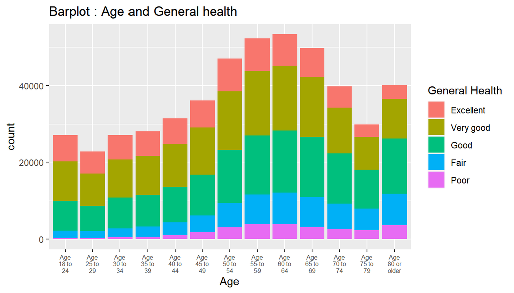

```r
ggplot(brfss2013_r1, aes(X_ageg5yr, fill = genhlth), fig.width = 20)  + geom_bar(position = "stack") + ggtitle("Barplot : Age and General health") + theme(axis.text.x = element_text(size= 6)) + aes(stringr::str_wrap(X_ageg5yr, 5)) + labs(y= "count", x = "Age", fill = "General Health")
```

- The generation from 50 to 70 years old takes biggest part in this dataset. Most people feel pretty good about their general health. But we can say it could be general that the older people are, the ratio of feeling good is getting less and feel poorer compared to being younger.

**Research quesion 2: When subjects are in same generation and have similar drinks consumption, is there any difference between physically active and inactive people in general health?**

```r
# Let's see how physical activity is categorized and summarize it.

brfss2013 %>% group_by(X_pacat1) %>% summarise(count=n())
```

```
## # A tibble: 5 x 2
##   X_pacat1               count
##   <fct>                  <int>
## 1 Highly active         134765
## 2 Active                 71513
## 3 Insufficiently active  77787
## 4 Inactive              130832
## 5 <NA>                   76878
```

```r
# Mutate physical activity into 2 types, active and inactive.

brfss2013_r2 <- brfss2013 %>% filter(!is.na(X_pacat1)) %>%
  mutate(physical_activity = ifelse(X_pacat1 == 'Highly active',"Active",
                                    ifelse(X_pacat1 == 'Active',"Active",
                                           ifelse(X_pacat1 == 'Insufficiently active',"Inactive",
                                                  ifelse(X_pacat1 == 'Inactive',"Inactive",'')))))
brfss2013_r2 %>% group_by(physical_activity) %>% summarise(count=n())
```

```
## # A tibble: 2 x 2
##   physical_activity  count
##   <chr>              <int>
## 1 Active            206278
## 2 Inactive          208619
```

```r
# What about age distribution?

brfss2013 %>% group_by(X_ageg5yr) %>% summarise(count=n())
```

```
## # A tibble: 14 x 2
##    X_ageg5yr       count
##    <fct>           <int>
##  1 Age 18 to 24    27202
##  2 Age 25 to 29    22910
##  3 Age 30 to 34    27213
##  4 Age 35 to 39    28107
##  5 Age 40 to 44    31508
##  6 Age 45 to 49    36210
##  7 Age 50 to 54    47173
##  8 Age 55 to 59    52491
##  9 Age 60 to 64    53659
## 10 Age 65 to 69    49997
## 11 Age 70 to 74    39967
## 12 Age 75 to 79    30093
## 13 Age 80 or older 40515
## 14 <NA>             4730
```

```r
# I would like to transform the age unit into generation.

brfss2013_r2 <- brfss2013_r2 %>% filter(!is.na(X_ageg5yr)) %>%
  mutate(age = ifelse(X_ageg5yr == 'Age 18 to 24',"20's",
                                    ifelse(X_ageg5yr == 'Age 25 to 29',"20's",
                                           ifelse(X_ageg5yr == 'Age 30 to 34',"30's",
                                                  ifelse(X_ageg5yr == 'Age 35 to 39',"30's",
                                                         ifelse(X_ageg5yr == 'Age 40 to 44',"40's",
                                                                ifelse(X_ageg5yr == 'Age 45 to 49',"40's",
                                                                       ifelse(X_ageg5yr == 'Age 50 to 54',"50's",
                                                                              ifelse(X_ageg5yr == 'Age 55 to 59',"50's",
                                                                                     "60's or older")))))))))


brfss2013_r2 %>% group_by(age) %>% summarise(count=n())
```

```
## # A tibble: 5 x 2
##   age            count
##   <chr>          <int>
## 1 20's           40752
## 2 30's           46204
## 3 40's           58167
## 4 50's           86655
## 5 60's or older 182154
```

```r
# Mutate Computed Number Of Drinks Of Alcohol Beverages Per Day into drinker level.
# I set the drinker level with non-drinker, light (less than 5 drinks) , middle (less than 10 drinks) and heavy drinker (more than 10).

brfss2013_r2 <- brfss2013_r2 %>% filter(!is.na(X_drnkdy4)) %>%
  mutate(alcohol_consumption = ifelse(X_drnkdy4 == 0,"Non",
                                    ifelse(X_drnkdy4 <= 5,"Light",
                                           ifelse(X_drnkdy4 <= 10,"Middle",
                                                  ifelse(X_drnkdy4 >10,"Heavy",'')))))

brfss2013_r2 %>% group_by(alcohol_consumption) %>% summarise(count=n())
```

```
## # A tibble: 4 x 2
##   alcohol_consumption  count
##   <chr>                <int>
## 1 Heavy               151788
## 2 Light                23077
## 3 Middle               26927
## 4 Non                 205531
```

```r
# 2 implied decimal places should be applied to bmi values.

brfss2013_r2 <- brfss2013_r2 %>% mutate(bmi_value = X_bmi5*0.01) %>%
  mutate(bmi = ifelse(bmi_value < 100, bmi_value, NA)) %>% filter(!is.na(bmi))

# Check it how the dataset can be summarized with physically active people.

brfss2013_r2 %>% group_by(physical_activity, age, alcohol_consumption) %>%
  summarise(count=n(), mean_bmi = mean(bmi)) %>% filter(physical_activity == 'Active')
```

```
## # A tibble: 20 x 5
## # Groups:   physical_activity, age [5]
##    physical_activity age           alcohol_consumption count mean_bmi
##    <chr>             <chr>         <chr>               <int>    <dbl>
##  1 Active            20's          Heavy                9725     25.6
##  2 Active            20's          Light                 898     26.9
##  3 Active            20's          Middle               1268     26.0
##  4 Active            20's          Non                  7482     25.9
##  5 Active            30's          Heavy               10481     26.9
##  6 Active            30's          Light                1160     27.9
##  7 Active            30's          Middle               1673     27.3
##  8 Active            30's          Non                  7772     28.2
##  9 Active            40's          Heavy               13089     26.8
## 10 Active            40's          Light                1603     28.1
## 11 Active            40's          Middle               2180     27.7
## 12 Active            40's          Non                 10231     28.4
## 13 Active            50's          Heavy               19042     26.7
## 14 Active            50's          Light                2440     28.2
## 15 Active            50's          Middle               2968     27.6
## 16 Active            50's          Non                 16384     28.2
## 17 Active            60's or older Heavy               33717     26.3
## 18 Active            60's or older Light                5122     27.4
## 19 Active            60's or older Middle               5505     27.1
## 20 Active            60's or older Non                 43613     27.1
```

```r
brfss2013_r2 <- brfss2013_r2 %>% group_by(physical_activity, age, alcohol_consumption) %>%
  summarise(count=n(), mean_bmi = mean(bmi)) %>% mutate(age_drink_type = paste(age,alcohol_consumption)) %>%
  select(physical_activity, age_drink_type, mean_bmi)
brfss2013_r2
```

```
## # A tibble: 40 x 4
## # Groups:   physical_activity, age [10]
##    age   physical_activity age_drink_type mean_bmi
##    <chr> <chr>             <chr>             <dbl>
##  1 20's  Active            20's Heavy         25.6
##  2 20's  Active            20's Light         26.9
##  3 20's  Active            20's Middle        26.0
##  4 20's  Active            20's Non           25.9
##  5 30's  Active            30's Heavy         26.9
##  6 30's  Active            30's Light         27.9
##  7 30's  Active            30's Middle        27.3
##  8 30's  Active            30's Non           28.2
##  9 40's  Active            40's Heavy         26.8
## 10 40's  Active            40's Light         28.1
## # ... with 30 more rows
```

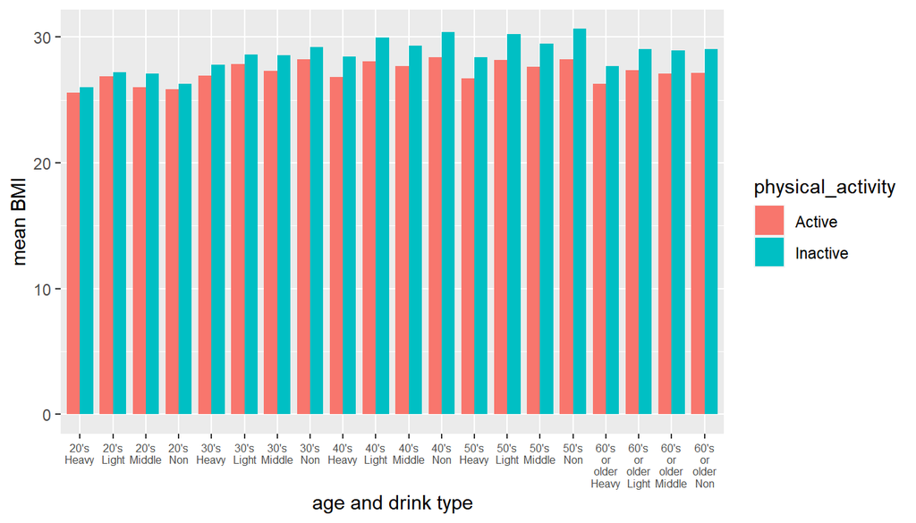

```r
ggplot(brfss2013_r2, aes(x = age_drink_type, y = mean_bmi, fill = physical_activity)) + geom_bar(stat = 'identity', position = 'dodge',width = 0.8) + theme(axis.text.x = element_text(size= 6)) + aes(stringr::str_wrap(age_drink_type, 5)) + labs(x = 'age and drink type', y = 'mean BMI')
```

- Overall, BMI level is lower in all generation when people are physically active compared when peoplare are not. The difference of BMI between active and inactive people are not that great in younger generation such as less then 40’s regardless drink type. But after 30’s the difference seems slightly bigger. As we know, people with higher BMI are likely to have obesity. Regardless of drink type, people have lower BMI when they do workout.

**Research quesion 3: Does income level affect to satisfaction of life?**

```r
# Let's see how the values are distributed.

brfss2013 %>% group_by(income2) %>% summarise(count=n())
```

```
## # A tibble: 9 x 2
##   income2            count
##   <fct>              <int>
## 1 Less than $10,000  25441
## 2 Less than $15,000  26794
## 3 Less than $20,000  34873
## 4 Less than $25,000  41732
## 5 Less than $35,000  48867
## 6 Less than $50,000  61509
## 7 Less than $75,000  65231
## 8 $75,000 or more   115902
## 9 <NA>               71426
```

```r
brfss2013 %>% group_by(lsatisfy) %>% summarise(count=n())
```

```
## # A tibble: 5 x 2
##   lsatisfy           count
##   <fct>              <int>
## 1 Very satisfied      5393
## 2 Satisfied           5518
## 3 Dissatisfied         599
## 4 Very dissatisfied    161
## 5 <NA>              480104
```

```r
# Remove NA values in both columns

brfss2013_r3 <- brfss2013 %>% filter(!is.na(income2)& !is.na(lsatisfy)) %>% select(income2, lsatisfy)
brfss2013_r3 %>% group_by(income2) %>% summarise(count=n())
```

```
## # A tibble: 8 x 2
##   income2           count
##   <fct>             <int>
## 1 Less than $10,000   864
## 2 Less than $15,000   985
## 3 Less than $20,000  1039
## 4 Less than $25,000  1044
## 5 Less than $35,000  1179
## 6 Less than $50,000  1274
## 7 Less than $75,000  1241
## 8 $75,000 or more    1706
```

```r
brfss2013_r3 %>% group_by(lsatisfy) %>% summarise(count=n())
```

```
## # A tibble: 4 x 2
##   lsatisfy          count
##   <fct>             <int>
## 1 Very satisfied     4290
## 2 Satisfied          4418
## 3 Dissatisfied        490
## 4 Very dissatisfied   134
```

```r
brfss2013_r3 %>% group_by(income2, lsatisfy) %>% summarise(count=n())
```

```
## # A tibble: 32 x 3
## # Groups:   income2 [8]
##    income2           lsatisfy          count
##    <fct>             <fct>             <int>
##  1 Less than $10,000 Very satisfied      238
##  2 Less than $10,000 Satisfied           461
##  3 Less than $10,000 Dissatisfied        113
##  4 Less than $10,000 Very dissatisfied    52
##  5 Less than $15,000 Very satisfied      309
##  6 Less than $15,000 Satisfied           548
##  7 Less than $15,000 Dissatisfied        101
##  8 Less than $15,000 Very dissatisfied    27
##  9 Less than $20,000 Very satisfied      374
## 10 Less than $20,000 Satisfied           594
## # ... with 22 more rows
```

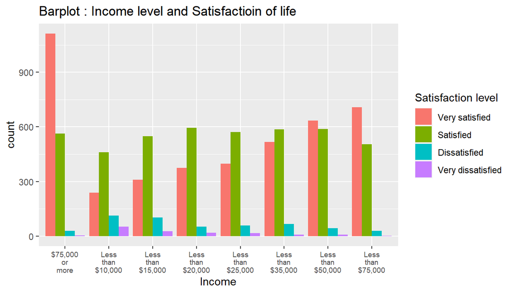

```r
# Make a plot and see the distribution

ggplot(brfss2013_r3, aes(income2))  + geom_bar(aes(fill=lsatisfy), position = 'dodge') + ggtitle("Barplot : Income level and Satisfactioin of life") + theme(axis.text.x = element_text(size= 7)) + aes(stringr::str_wrap(income2, 5)) + labs(y= "count", x = "Income", fill = "Satisfaction level")
```

- As you can see, the more income people have, they tend to feel very satisfied with their life and feel less dissatisfied. But generally people are satisfied with their life regardless of income level. Although the number of rows in this dataset were deleted becasue of too many NA values, we can still see the increase of ‘very satisfied’ when people earn more money.